## 绘制交叉验证曲线

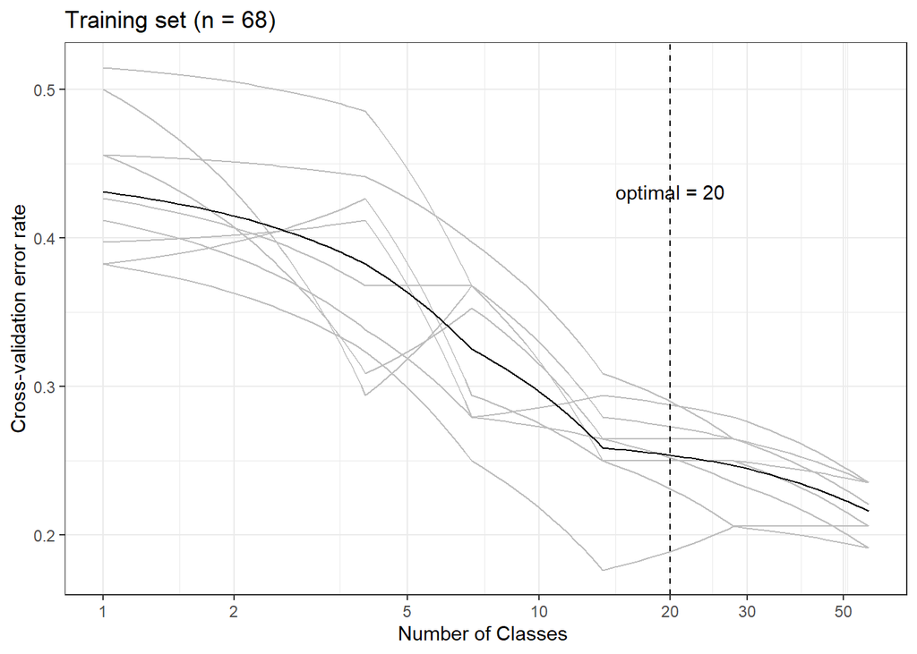

```r
# 提取x轴标签
n.var = error.cv0$num
# 提取y轴数据+标签
# error.cv = error.cv0[,2:6]
# colnames(error.cv) = paste('err',1:5,sep='.')
error.cv = error.cv0[,2:11]
colnames(error.cv) = paste('err',1:10,sep='.')


# 添加均值
err.mean = apply(error.cv,1,mean)
# 合并新的数据库，x+error+mean
allerr = data.frame(num=n.var,err.mean=err.mean,error.cv)
# number of otus selected 人为在图中观察的结果，30几乎为最低，且数量可接受
optimal = 20

# 图1：机器学习结果交叉验证图，选择Top features
# 图中 + 5条灰色拆线+1条黑色均值拆线+一条最优垂线+X轴对数变换
write.table(allerr, file = rfcv_filename_txt, sep = "\t", quote = F, row.names = T, col.names = T)

p = ggplot() + # 开始绘图
  geom_line(aes(x = allerr$num, y = allerr$err.1), colour = 'grey') + # 5次验证灰线
  geom_line(aes(x = allerr$num, y = allerr$err.2), colour = 'grey') +
  geom_line(aes(x = allerr$num, y = allerr$err.3), colour = 'grey') +
  geom_line(aes(x = allerr$num, y = allerr$err.4), colour = 'grey') +
  geom_line(aes(x = allerr$num, y = allerr$err.5), colour = 'grey') +
  geom_line(aes(x = allerr$num, y = allerr$err.6), colour = 'grey') + # 5次验证灰线
  geom_line(aes(x = allerr$num, y = allerr$err.7), colour = 'grey') +
  geom_line(aes(x = allerr$num, y = allerr$err.8), colour = 'grey') +
  geom_line(aes(x = allerr$num, y = allerr$err.9), colour = 'grey') +
  geom_line(aes(x = allerr$num, y = allerr$err.10), colour = 'grey') +
  geom_line(aes(x = allerr$num, y = allerr$err.mean), colour = 'black') + # 均值黑线
  geom_vline(xintercept = optimal, colour='black', lwd=0.36, linetype="dashed") + # 最优垂线
  coord_trans(x = "log2") + # X轴对数变换和刻度
  scale_x_continuous(breaks = c(1, 2, 5, 10, 20, 30, 50, 100, 200)) + # , max(allerr$num)
  labs(title=paste('Training set (n = ', dim(t(otu_sub1))[1],')', sep = ''),
       x='Number of Classes ', y='Cross-validation error rate') +
  annotate("text", x = optimal, y = max(allerr$err.mean), label=paste("optimal = ", optimal, sep="")) + theme_bw()
p
```

```r
ggsave(p, file = rfcv_filename_pdf, width = 180, height = 120, unit = 'mm')
```

## 特征重要性可视化

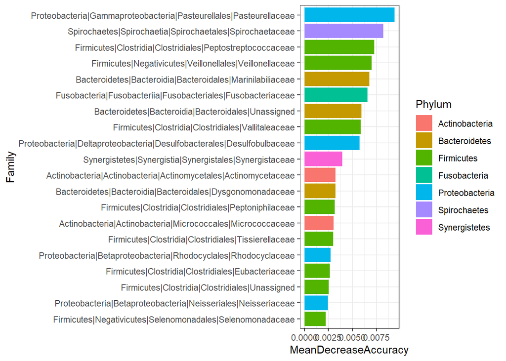

```r
## 预览和保存特征贡献度
imp= as.data.frame(rf3$importance)
imp = imp[order(imp$MeanDecreaseAccuracy, decreasing = T),]
# bbb = head(imp,n=optimal)
write.table(imp,file = importance_filename_txt,quote = F,sep = '\t', row.names = T, col.names = T)
# 简单可视化，比较丑
# varImpPlot(rf, main = "Feature importance",n.var = optimal, bg = par("bg"), color = par("fg"), gcolor = par("fg"), lcolor = "gray" )

# 图2. Feature重要性：绘制条形图+门属性着色

# 读取所有feature贡献度
imp2 = read.table(importance_filename_txt, header=T, row.names= 1, sep="\t")
# 分析选择top20分组效果最好，参数显示数量
imp2 = head(imp2, n = optimal)
imp2 = imp2[order(imp2$MeanDecreaseAccuracy, decreasing = F),]
# 简化全名，去掉界
imp2$Family = gsub("Bacteria\\|","",rownames(imp2))
# 添加门用于着色(删除竖线后面全部)
imp2$Phylum = gsub("\\|.*","",imp2$Family)

# 设置顺序
imp2$Family = factor(imp2$Family, levels = imp2$Family)

# 图2. 绘制物种类型种重要性柱状图
p = ggplot(imp2, aes(x = Family, y = MeanDecreaseAccuracy, fill = Phylum)) +
  geom_bar(stat = "identity") +
  coord_flip() + theme_bw()
p
```

```r
ggsave(top_feautre_filename, p, width=89*2.5, height=59*2, unit='mm')
# 名称不一定唯一，需要手动修改

#  简化全名(只保留最后，有重名不可用，可选)
# imp$Family = gsub(".*\\|","",imp$Family)
# imp$Family = factor(imp$Family, levels = imp$Family)
# p = ggplot(imp, aes(x = Family, y = MeanDecreaseAccuracy, fill = Phylum)) +
#   geom_bar(stat = "identity") +
#   coord_flip() + theme_bw()
# p
# ggsave(paste("top_feautre",".pdf", sep=""), p, width=89*1.5, height=59*1.5, unit='mm')
```

## 测试集独立验证

如果第一地点数据量足够大，可以取出1/2到1/3进行同一地点的独立验证。方法相同。

筛选测序集样品

```r
test = subset(metadata_f, DayE %in% c("pre"))


#test = metadata_f[!idx3,]
metadata_test = test
summary(metadata_test)
```

```
##    Filename          Group_day          Group_day1         Group_dayE
##  Length:68          Length:68          Length:68          Length:68
##  Class :character   Class :character   Class :character   Class :character
##  Mode  :character   Mode  :character   Mode  :character   Mode  :character
##
##
##
##   Group_dayS           Group            StateSite         StateSite_1
##  Length:68          Length:68          Length:68          Length:68
##  Class :character   Class :character   Class :character   Class :character
##  Mode  :character   Mode  :character   Mode  :character   Mode  :character
##
##
##
##     State               Site              Site_1               Day
##  Length:68          Length:68          Length:68          Min.   :0
##  Class :character   Class :character   Class :character   1st Qu.:0
##  Mode  :character   Mode  :character   Mode  :character   Median :0
##                                                           Mean   :0
##                                                           3rd Qu.:0
##                                                           Max.   :0
##     Day_num      Day1               DayE            Individual
##  Min.   :0   Length:68          Length:68          Length:68
##  1st Qu.:0   Class :character   Class :character   Class :character
##  Median :0   Mode  :character   Mode  :character   Mode  :character
##  Mean   :0
##  3rd Qu.:0
##  Max.   :0
```

```r
idx4 = rownames(metadata_test) %in% colnames(table)
metadata_test = metadata_test[idx4,]
otu_sub2 = table[,rownames(metadata_test)]



# 转置，并添加分组信息
otutab_t2 = as.data.frame(t(otu_sub2))
otutab_t2$StateSite = metadata_test[rownames(otutab_t2),]$StateSite
```

基于训练集随机森林模型验证

```r
set.seed(333)
otutab.pred = predict(rf3, t(otu_sub2) )
pre_tab = table(observed=otutab_t2[,"StateSite"],
                predicted=otutab.pred)
pre_tab
```

```
##         predicted
## observed DS HS
##       DS  9  8
##       HS 13 38
```

可视化验证结果

```r
# 整理样本原始分组和预测分类
predict = data.frame(group = otutab_t2[,"StateSite"], predicted=otutab.pred)

# 保存预测结果表
write.table("SampleID\t", file=prediction_filename,append = F, quote = F, eol = "", row.names = F, col.names = F)
write.table(predict, file = prediction_filename,append = T, quote = F, row.names = T, col.names = T, sep = "\t")
# 转换为数值可视化
# 预测准确标为1，错误标为0
predict$result = ifelse(predict$group == predict$predicted, 1, 0)
# IND=1, TEJ=2
predict$predict = ifelse(predict$predicted == "DS", 1, 2)
# Set sample number in each row
column1 = 7
column = 7
low_to_high_colors <- colorRampPalette(c("#B1DDE1", "#F8C7BD"))(100)

AA1 = predict[predict$group=="DS",]$predict
length(AA1)
```

```
## [1] 17
```

```r
row = round(length(AA1)/column1 + 0.5)
row
```

```
## [1] 3
```

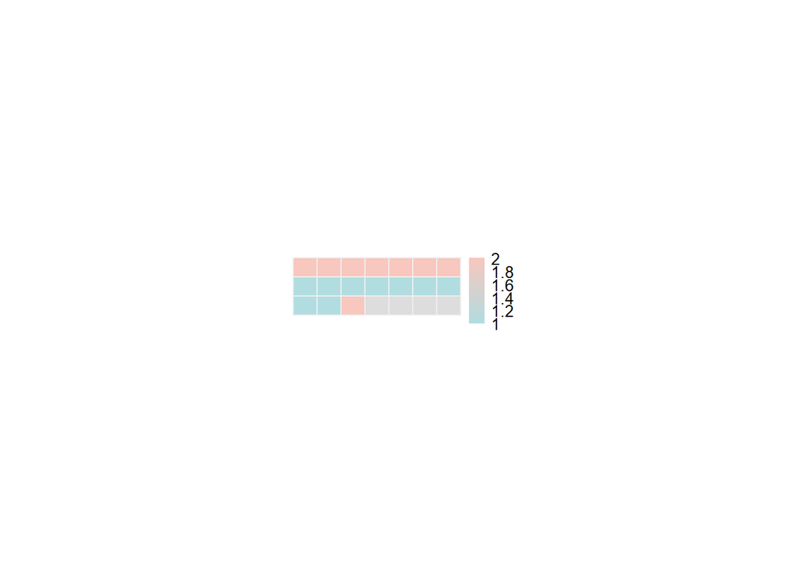

```r
i = column1 * row - length(AA1)
AA1 = c(AA1, rep(NA, i))
matrix1 = matrix(AA1, nrow = row, ncol = column1, byrow = T)
pheatmap(matrix1, cluster_rows = F, cluster_cols = F, cellwidth = 15, cellheight = 12, color = low_to_high_colors, border_color = "#EFEFEF")
```

```r
#pheatmap(matrix1, cluster_rows = F, cluster_cols = F, cellwidth = 15, cellheight = 12,filename = "family_test_DD.pdf")
pheatmap(matrix1, cluster_rows = F, cluster_cols = F, cellwidth = 18, cellheight = 18,filename = testfilename1, color = low_to_high_colors, border_color = "#EFEFEF")
# Draw TEJ prediction result
BB1 = predict[predict$group=="HS",]$predict
length(BB1)
```

```
## [1] 51
```

```r
row = round(length(BB1)/column + 0.5)
i = column * row - length(BB1)
BB1 = c(BB1, rep(NA, i))
matrix2 = matrix(BB1, nrow = row, ncol = column, byrow = T)
pheatmap(matrix2, cluster_rows = F, cluster_cols = F, cellwidth = 15, cellheight = 12, color = low_to_high_colors, border_color = "#EFEFEF")
# 保存图片
#pheatmap(matrix2, cluster_rows = F, cluster_cols = F, cellwidth = 18, cellheight = 18, filename = "family_test_HH.pdf")
pheatmap(matrix2, cluster_rows = F, cluster_cols = F, cellwidth = 18, cellheight = 18, filename = testfilename2, color = low_to_high_colors, border_color = "#EFEFEF")



## 将生成的文件放入指定文件夹
source_dir <- "C:/16S/result/randomforestclassification"
target_dir <- result_file_names

if (!dir.exists(target_dir)) {
  dir.create(target_dir)
}

# 选取含特定字符的文件（例如后缀为 csv 的所有文件）
tobeCopy1 <- list.files(source_dir, pattern = "*_rf.txt", full.names = TRUE)
tobeCopy2 <- list.files(source_dir, pattern = "*_rf.pdf", full.names = TRUE)

# 复制选中文件到目标文件夹
sapply(tobeCopy1, function(x) { file.copy(x, target_dir, overwrite = TRUE) })
```

[output not shown]

[output not shown]

```
##        C:/16S/result/randomforestclassification/new_importance_pre_D_H_rf.txt
##                                                                          TRUE
## C:/16S/result/randomforestclassification/new_prediction_binary_pre_D_H_rf.txt
##                                                                          TRUE
##              C:/16S/result/randomforestclassification/new_rfcv_pre_D_H_rf.txt
##                                                                          TRUE
##          C:/16S/result/randomforestclassification/sub_metadata_pre_D_H_rf.txt
##                                                                          TRUE
```

```r
sapply(tobeCopy2, function(x) { file.copy(x, target_dir, overwrite = TRUE) })
```

```
##         C:/16S/result/randomforestclassification/new_rfcv_pre_D_H_rf.pdf
##                                                                     TRUE
##           C:/16S/result/randomforestclassification/new_test_pre_D_rf.pdf
##                                                                     TRUE
##           C:/16S/result/randomforestclassification/new_test_pre_H_rf.pdf
##                                                                     TRUE
## C:/16S/result/randomforestclassification/new_top_feautres_pre_D_H_rf.pdf
##                                                                     TRUE
```

```r
# 删除源文件夹中的已复制文件
file.remove(tobeCopy1)
```

```
## [1] TRUE TRUE TRUE TRUE
```

```r
file.remove(tobeCopy2)
```

```
## [1] TRUE TRUE TRUE TRUE
```

```r
# 确认文件已经复制和删除
print("Files copied and deleted successfully.")
```

```
## [1] "Files copied and deleted successfully."
```

使用此脚本，请引用下文：

If used this script, please cited:

**Yong-Xin Liu**, Lei Chen, Tengfei Ma, Xiaofang Li, Maosheng Zheng, Xin Zhou, Liang Chen, Xubo Qian, Jiao Xi, Hongye Lu, Huiluo Cao, Xiaoya Ma, Bian Bian, Pengfan Zhang, Jiqiu Wu, Ren-You Gan, Baolei Jia, Linyang Sun, Zhicheng Ju, Yunyun Gao, **Tao Wen**, **Tong Chen**. 2023. EasyAmplicon: An easy-to-use, open-source, reproducible, and community-based pipeline for amplicon data analysis in microbiome research. **iMeta** 2: e83. https://doi.org/10.1002/imt2.83

Copyright 2016-2023 Yong-Xin Liu liuyongxin@caas.cn, Tao Wen taowen@njau.edu.cn, Tong Chen chent@nrc.ac.cn